# Analysis on pairwise competition assays

Chang-Yu Chang

2022-06-09

# 02A pairs experiments

- Experiment-related scripts
- Read pairwise competition outcomes that are determined by colony counts on plates.
- Read CASEU results
- Map pairs and isolates to the 96-well plate layout

## Read the pairwise competitive outcomes determined by colony counting on TSA

The script below generates the table for manual key-in

```r
if (FALSE) source(\script/02A-pairs_experiment-01-pairwise_manual_key_in.R\)
```

Then I manually checked the scanned plate images of competitive pairs. The plate images are saved in folder `data/raw/plate_scan/emergent_coexistence_plate_scan/` divided according to the experimental batches.

| Batch | Community |
| --- | --- |
| B2 | 2.6, 2.8, 7.1, 8.4, 10.2, 11.1 |
| C | 11.1 isolate 1 |
| C2 | 11.2 |
| D | 1.2, 1.4, 1.6, 1.7, 4.1, 11.5 |

````r
```r
# Read result colony counts and dilution factor
if (run_scripts) source(\script/02A-pairs_experiment-02-colony_count.R\)
````

[output not shown]

| Batch | Community | Isolate1 | Isolate2 | Isolate1Freq | Isolate2Freq | ColonyCount | ColonyCount1 | ColonyCount2 | Contamination | DilutionFactor |
| --- | --- | --- | --- | --- | --- | --- | --- | --- | --- | --- |
| D | C4R1 | 1 | 2 | 5 | 95 | 164 | 0 | 164 | FALSE | 5 |
| D | C4R1 | 1 | 2 | 50 | 50 | 134 | 133 | 1 | FALSE | 5 |
| D | C4R1 | 1 | 2 | 95 | 5 | 70 | 65 | 5 | FALSE | 5 |
| D | C4R1 | 1 | 3 | 5 | 95 | NA | NA | NA | FALSE | 4 |
| D | C4R1 | 1 | 3 | 50 | 50 | NA | NA | NA | FALSE | 4 |
| D | C4R1 | 1 | 3 | 95 | 5 | NA | NA | NA | FALSE | 4 |
| D | C4R1 | 2 | 3 | 5 | 95 | 63 | 60 | 3 | FALSE | 5 |
| D | C4R1 | 2 | 3 | 50 | 50 | 135 | 135 | 0 | FALSE | 5 |
| D | C4R1 | 2 | 3 | 95 | 5 | 124 | 124 | 0 | FALSE | 5 |
| B2 | C8R4 | 1 | 2 | 5 | 95 | 106 | 17 | 89 | FALSE | 5 |

[output cut: 548 more lines]

67 of of 558 pair-frequency without determined outcomes of pairwise competitions will be determined by using CASEU method

```r
pairs_competition %>% filter(is.na(ColonyCount))
```

| Batch | Community | Isolate1 | Isolate2 | Isolate1Freq | Isolate2Freq | ColonyCount | ColonyCount1 | ColonyCount2 | Contamination | DilutionFactor |
| --- | --- | --- | --- | --- | --- | --- | --- | --- | --- | --- |
| D | C4R1 | 1 | 3 | 5 | 95 | NA | NA | NA | FALSE | 4 |
| D | C4R1 | 1 | 3 | 50 | 50 | NA | NA | NA | FALSE | 4 |
| D | C4R1 | 1 | 3 | 95 | 5 | NA | NA | NA | FALSE | 4 |
| B2 | C8R4 | 1 | 3 | 5 | 95 | NA | NA | NA | FALSE | 5 |
| B2 | C8R4 | 1 | 3 | 50 | 50 | NA | NA | NA | FALSE | 5 |
| B2 | C8R4 | 1 | 3 | 95 | 5 | NA | NA | NA | FALSE | 5 |
| B2 | C2R6 | 1 | 3 | 5 | 95 | NA | NA | NA | FALSE | 5 |
| B2 | C2R6 | 1 | 3 | 50 | 50 | NA | NA | NA | FALSE | 5 |
| B2 | C2R6 | 1 | 3 | 95 | 5 | NA | NA | NA | FALSE | 5 |
| B2 | C2R8 | 3 | 4 | 5 | 95 | NA | NA | NA | FALSE | 5 |

[output cut: 57 more lines]

186 pair IDs saved in `data/temp/pairs_ID.csv`

```r
pairs_ID <- read_csv("~/Dropbox/lab/emergent-coexistence/data/temp/pairs_ID.csv", col_types = cols())
pairs_ID
```

| PairID | Community | Isolate1 | Isolate2 |
| --- | --- | --- | --- |
| 1 | C4R1 | 1 | 2 |
| 2 | C4R1 | 1 | 3 |
| 3 | C4R1 | 2 | 3 |
| 4 | C8R4 | 1 | 2 |
| 5 | C8R4 | 1 | 3 |
| 6 | C8R4 | 2 | 3 |
| 7 | C10R2 | 1 | 2 |
| 8 | C10R2 | 1 | 3 |
| 9 | C10R2 | 2 | 3 |
| 10 | C1R2 | 1 | 2 |

[output cut: 176 more lines]

## Ambiguous pairs and isolates on TSA agar plates

````r
```r
if (run_scripts) source(\script/02A-pairs_experiment-03-pairwise_ambiguous.R\)
````

[output not shown]

| Batch | Community | Isolate1 | Isolate2 | Isolate1Freq | Isolate2Freq | Contamination |
| --- | --- | --- | --- | --- | --- | --- |
| D | C4R1 | 1 | 3 | 5 | 95 | FALSE |
| D | C4R1 | 1 | 3 | 50 | 50 | FALSE |
| D | C4R1 | 1 | 3 | 95 | 5 | FALSE |
| B2 | C8R4 | 1 | 3 | 5 | 95 | FALSE |
| B2 | C8R4 | 1 | 3 | 50 | 50 | FALSE |
| B2 | C8R4 | 1 | 3 | 95 | 5 | FALSE |
| B2 | C2R6 | 1 | 3 | 5 | 95 | FALSE |
| B2 | C2R6 | 1 | 3 | 50 | 50 | FALSE |
| B2 | C2R6 | 1 | 3 | 95 | 5 | FALSE |
| B2 | C2R8 | 3 | 4 | 5 | 95 | FALSE |

[output cut: 57 more lines]

In total, 28 pairs

| Community | Isolate1 | Isolate2 | Count |
| --- | --- | --- | --- |
| C11R1 | 1 | 2 | 1 |
| C11R1 | 1 | 3 | 1 |
| C11R1 | 1 | 4 | 1 |
| C11R1 | 2 | 8 | 3 |
| C11R1 | 2 | 9 | 1 |
| C11R2 | 2 | 8 | 3 |
| C11R2 | 3 | 6 | 1 |
| C11R2 | 3 | 7 | 3 |
| C11R2 | 3 | 12 | 3 |
| C11R2 | 5 | 6 | 2 |

[output cut: 18 more lines]

36 isolates involved in the ambiguous pairs.

```r
isolates_ambiguous <- read_csv("~/Dropbox/lab/emergent-coexistence/data/temp/isolates_ambiguous.csv", col_types = cols())
isolates_ambiguous
```

| Assembly | Community | Isolate | ExpID | ID |
| --- | --- | --- | --- | --- |
| self_assembly | C11R1 | 1 | 11.1.A.1 | 335 |
| self_assembly | C11R1 | 2 | 11.1.A.2 | 452 |
| self_assembly | C11R1 | 3 | 11.1.A.3 | 336 |
| self_assembly | C11R1 | 4 | 11.1.A.4 | 332 |
| self_assembly | C11R1 | 8 | 11.1.C.2 | 341 |
| self_assembly | C11R1 | 9 | 11.1.C.3 | 342 |
| self_assembly | C11R2 | 2 | 11.2.A.2 | 453 |
| self_assembly | C11R2 | 3 | 11.2.A.3 | 344 |
| self_assembly | C11R2 | 5 | 11.2.B.1 | 346 |
| self_assembly | C11R2 | 6 | 11.2.B.2 | 280 |

[output cut: 26 more lines]

## Map pairs and isolates to the DW96 plate layout

```r
plates_name <- c("plate_B2_933", "plate_B2_444", "plate_C_C11R1", "plate_C2_13A", "plate_C2_13B", "plate_D_75", "plate_D_5543")
source("script/02A-pairs_experiment-04-pairwise_plate_layout.R")
```

Each plate has 96 rows and has the following variables

```r
plates <- read_csv("~/Dropbox/lab/emergent-coexistence/data/output/plates.csv", col_types = cols())
plates
```

| Batch | PlateLayout | Well | MixIsolate | Community | Isolate1 | Isolate2 | Plate | Isolate1Freq | Isolate2Freq |
| --- | --- | --- | --- | --- | --- | --- | --- | --- | --- |
| B2 | 933 | A01 | TRUE | C11R1 | 1 | 1 | P1 | 50 | 50 |
| B2 | 933 | A02 | TRUE | C11R1 | 1 | 2 | P1 | 50 | 50 |
| B2 | 933 | A03 | TRUE | C11R1 | 1 | 3 | P1 | 50 | 50 |
| B2 | 933 | A04 | TRUE | C11R1 | 1 | 4 | P1 | 50 | 50 |
| B2 | 933 | A05 | TRUE | C11R1 | 1 | 5 | P1 | 50 | 50 |
| B2 | 933 | A06 | TRUE | C11R1 | 1 | 6 | P1 | 50 | 50 |
| B2 | 933 | A07 | TRUE | C11R1 | 1 | 7 | P1 | 50 | 50 |
| B2 | 933 | A08 | TRUE | C11R1 | 1 | 8 | P1 | 50 | 50 |
| B2 | 933 | A09 | TRUE | C11R1 | 1 | 9 | P1 | 50 | 50 |
| B2 | 933 | A10 | TRUE | C8R4 | 1 | 1 | P1 | 50 | 50 |

[output cut: 990 more lines]

Plates for across-community and random assembly

```r
plates_random <- read_csv("~/Dropbox/lab/emergent-coexistence/data/output/plates_random.csv", col_types = cols())
plates_random
```

| PlateLayout | MixPlate | Well | Community | Isolate1 | Isolate2 | MixIsolate | Isolate1Freq | Isolate2Freq |
| --- | --- | --- | --- | --- | --- | --- | --- | --- |
| AD | P1 | A01 | AcrAss1 | 1 | 1 | TRUE | 0.50 | 0.50 |
| AD | P1 | B01 | AcrAss1 | 2 | 1 | TRUE | 0.50 | 0.50 |
| AD | P1 | C01 | AcrAss1 | 3 | 1 | TRUE | 0.50 | 0.50 |
| AD | P1 | D01 | AcrAss1 | 4 | 1 | TRUE | 0.50 | 0.50 |
| AD | P1 | E01 | AcrAss1 | 5 | 1 | TRUE | 0.50 | 0.50 |
| AD | P1 | F01 | AcrAss1 | 6 | 1 | TRUE | 0.50 | 0.50 |
| AD | P1 | G01 | AcrAss1 | 7 | 1 | TRUE | 0.50 | 0.50 |
| AD | P1 | H01 | AcrAss1 | 8 | 1 | TRUE | 0.50 | 0.50 |
| AD | P1 | A02 | AcrAss1 | 1 | 2 | TRUE | 0.50 | 0.50 |
| AD | P1 | B02 | AcrAss1 | 2 | 2 | TRUE | 0.50 | 0.50 |

[output cut: 854 more lines]

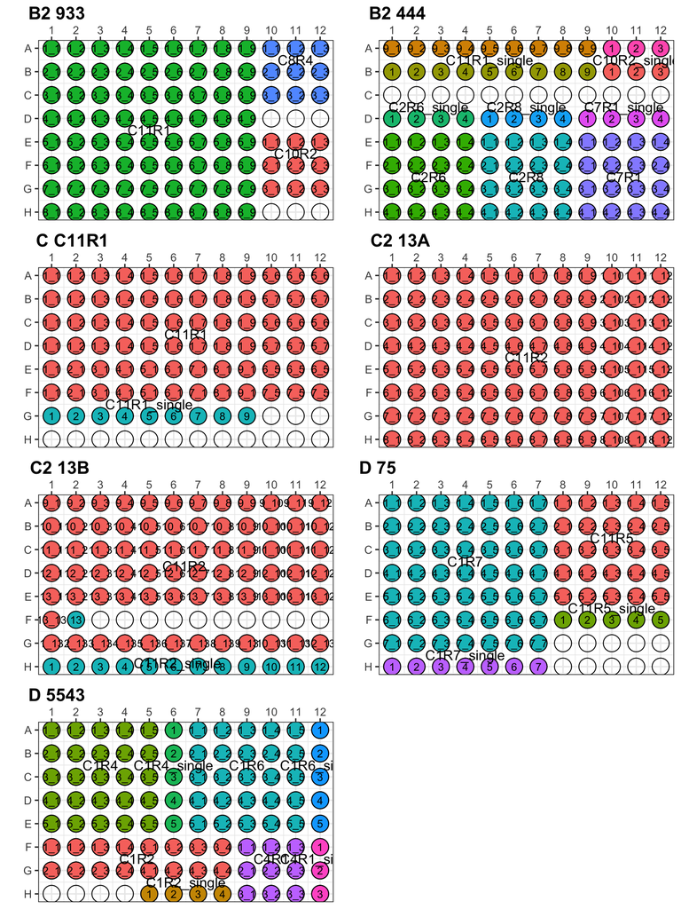

```r
plates_list <- plates %>%
    filter(Plate == "P1") %>%
    distinct(Batch, PlateLayout) %>%
    rename(batch = Batch, platelayout = PlateLayout) %>%
    rowwise() %>%
    mutate(plate = filter(plates, Batch == batch, PlateLayout == platelayout, Plate == "P1") %>% list) %>%
    mutate(plate = prepare_plate_draw(plate) %>% list) %>%
    mutate(p_plate = draw_plate_from_df(plate) %>% list)

plot_grid(plotlist = plates_list$p_plate, labels = paste0(plates_list$batch, " ", plates_list$platelayout),
          ncol = 2)
```

Plate layout that takes different initial frequencies:

- P1 is 50%:50%.
- P2 and P3 are identical and whose rows are 95% and columns are 5%.

The only exception is plate C11R1 in batch C, which only has one plate.

[figure not shown]

# 02B CASEU sanger sequencing

- To determine the relative abundance of of ambiguous pairs in competitive assays.
- Use CASEU packages to analyse the Sanger sequencing of mixture culture.
- Sanger sequencing protocol preparation. Experimental protocol files are saved in folder `output/protocol/`

```r
list.files(here::here("output/protocol"), pattern = "caseu")
```

```
[1] "caseu_calibration.Rmd" "caseu_genewiz.pdf"     "caseu_genewiz.Rmd"     "caseu_pcr.pdf"
[5] "caseu_pcr.Rmd"         "caseu_protocol.pdf"    "caseu_protocol.Rmd"
```

- Once we got the mixture Sanger sequences back, we implement analysis by using `CASEU` (Compositional analysis by Sanger electropherogram unmixing), an R package designed for quantifying relative abundance of Sanger sequences mixture. [source code](https://bitbucket.org/DattaManoshi/caseu). Install `CASEU` from bitbucket.
- Check out [package vignette](https://htmlpreview.github.io/?https://bitbucket.org/dattamanoshi/caseu/raw/master/doc/CASEU_Vignette.html).

```r
devtools::install_bitbucket('dattamanoshi/caseu') # Install CASEU package
library(CASEU)
```

## Test on example data

```r
if (run_scripts) source("script/02B-CASEU_sanger_seq-00-test.R")
```

## CASEU pilot1

The plate layout of PCR plate and list of samples are specified in `output/protocol/protocol_20190813_Sanger_seq_prep.pdf`.

```r
read_csv("~/Dropbox/lab/emergent-coexistence/data/raw/Sanger/CASEU_pilot1/protocol_20190813_Sanger_seq_prep-genewiz_table.csv", col_types = cols())
```

| Sample # | DNA Name | Length (bp) | Concentration (ng/uL) | Primer | Difficult Template | Notes | Is Empty |
| --- | --- | --- | --- | --- | --- | --- | --- |
| 1 | A | 1000 | 0.83 | 27 | NA | NA | NA |
| 2 | B | 1000 | 0.83 | 27 | NA | NA | NA |
| 3 | C | 1000 | 0.83 | 27 | NA | NA | NA |
| 4 | D | 1000 | 0.83 | 27 | NA | NA | NA |
| 5 | OD_1_99_AB | 1000 | 0.83 | 27 | NA | NA | NA |
| 6 | OD_1_99_AC | 1000 | 0.83 | 27 | NA | NA | NA |
| 7 | OD_1_99_AD | 1000 | 0.83 | 27 | NA | NA | NA |
| 8 | OD_1_99_CD | 1000 | 0.83 | 27 | NA | NA | NA |
| 9 | OD_5_95_AB | 1000 | 0.83 | 27 | NA | NA | NA |
| 10 | OD_5_95_AC | 1000 | 0.83 | 27 | NA | NA | NA |

[output cut: 19 more lines]

The isolates used in this round is from the list below.

isolates

| Isolate | Code | Taxa |
| --- | --- | --- |
| C11R1 isolate 1 | A | Pseudomonas |
| C1R7 isolate 2 | B | Pseudomonas |
| C1R7 isolate 1 | C | Enterobacter |
| C1R7 isolate 7 | D | Raoultella |

Read trace matrices for isolates and mixtures

````r
```r
if(run_scripts) source(\script/02B-CASEU_sanger_seq-01-pilot1.R\)
````

[output not shown]

| Mixture | Repeat | Treatment | Isolate1 | Isolate2 | Isolate1Freq | Isolate1FreqPredicted |
| --- | --- | --- | --- | --- | --- | --- |
| OD_1_99_AB-27F.ab1 | FALSE | OD | A | B | 1 | 0.07007966 |
| OD_1_99_AC-27F.ab1 | FALSE | OD | A | C | 1 | 0.71749998 |
| OD_1_99_AD-27F.ab1 | FALSE | OD | A | D | 1 | 0.03954176 |
| OD_1_99_CD-27F.ab1 | FALSE | OD | C | D | 1 | 0.01620269 |
| OD_5_95_AB-27F.ab1 | FALSE | OD | A | B | 5 | 0.96517421 |
| OD_5_95_AC-27F.ab1 | FALSE | OD | A | C | 5 | 0.06891463 |
| OD_5_95_AD-27F.ab1 | FALSE | OD | A | D | 5 | 0.49199024 |
| OD_5_95_CD-27F.ab1 | FALSE | OD | C | D | 5 | 0.05025884 |
| OD_50_50_AB-27F.ab1 | FALSE | OD | A | B | 50 | 0.12662055 |
| OD_50_50_AC-27F.ab1 | FALSE | OD | A | C | 50 | 0.51090773 |

[output cut: 28 more lines]

## CASEU pilot2

```r
read_csv("~/Dropbox/lab/emergent-coexistence/data/raw/Sanger/CASEU_pilot2/protocol_20190910_Sanger_seq_prep-genewiz_table_CYC.csv", col_types = cols())
```

| Sample # | DNA Name | Length (bp) | Concentration (ng/uL) | Primer |
| --- | --- | --- | --- | --- |
| 1 | CYC_C11R1_50_50_12 | 1000 | 0.83 | 27 |
| 2 | CYC_C11R1_50_50_13 | 1000 | 0.83 | 27 |
| 3 | CYC_C11R1_50_50_14 | 1000 | 0.83 | 27 |
| 4 | CYC_C11R1_50_50_15 | 1000 | 0.83 | 27 |
| 5 | CYC_C11R1_50_50_16 | 1000 | 0.83 | 27 |
| 6 | CYC_C11R1_50_50_18 | 1000 | 0.83 | 27 |
| 7 | CYC_C11R1_50_50_19 | 1000 | 0.83 | 27 |
| 8 | CYC_C11R1_95_5_82 | 1000 | 0.83 | 27 |
| 9 | CYC_C11R1_50_50_23 | 1000 | 0.83 | 27 |
| 10 | CYC_C11R1_50_50_24 | 1000 | 0.83 | 27 |

[output cut: 38 more lines]

Isolates A B C D in control are the isolates below.

| Isolate | Code | Taxa |
| --- | --- | --- |
| C11R1 isolate 1 | A | Pseudomonas |
| C1R7 isolate 2 | B | Pseudomonas |
| C1R7 isolate 1 | C | Enterobacter |
| C1R7 isolate 7 | D | Raoultella |

```r
# Each script takes ~10 mins to run
source(\script/02B-CASEU_sanger_seq-02-pilot2.R\)
#source(\script/02B-CASEU_sanger_seq-03-pilot2_Sylvie.R\) # Run Sylvie's sequence
```

In the 12 control synthetic pairs that were made of 4 isolates, compare these pairs’ OD frequencies, colony counts, and CASEU predictions.

Read CASEU predicted frequencies and colony count frequencies in the 12 control pairs.

````r
```r
# Read data
CASEU_pilot2 <- read_csv(here::here(\data/temp/CASEU_pilot2.csv\))
CASEU_pilot2_plating <- read_csv(here::here(\data/raw/Sanger/CASEU_pilot2/CASEU_pilot2_plating.csv\)) %>%
  mutate(Isolate1ColonyFreq = Isolate1Colony / (Isolate1Colony + Isolate2Colony),
    Isolate2ColonyFreq = Isolate2Colony / (Isolate1Colony + Isolate2Colony))
````

[output not shown]

````r
```r
CASEU_pilot3 <- read_csv(here::here(\data/temp/CASEU_pilot3.csv\))
CASEU_pilot3 %>%
  mutate(Isolate1 = factor(Isolate1)) %>%
  ggplot(aes(x = Isolate1Freq, y = Isolate1FreqPredicted, color = Isolate1, group = paste0(Isolate1, \_\, Isolate2))) +
  geom_point() + geom_line() +
#  geom_abline(slope = 1, intercept = 0, color = \black\) +
  facet_wrap(.~Community) +
  theme_bw()
````

[output not shown]

| Sample # | DNA Name | Length (bp) | Concentration (ng/uL) | Primer |
| --- | --- | --- | --- | --- |
| 1 | C8R4_50_50_1_3 | 1000 | 0.83 | 27 |
| 2 | C8R4_95_5_1_3 | 1000 | 0.83 | 27 |
| 3 | C8R4_5_95_1_3 | 1000 | 0.83 | 27 |
| 4 | C2R6_50_50_1_3 | 1000 | 0.83 | 27 |
| 5 | C7R1_50_50_1_3 | 1000 | 0.83 | 27 |
| 6 | C7R1_50_50_1_4 | 1000 | 0.83 | 27 |
| 7 | C2R8_50_50_3_4 | 1000 | 0.83 | 27 |
| 8 | C2R6_95_5_1_3 | 1000 | 0.83 | 27 |
| 9 | C7R1_95_5_1_3 | 1000 | 0.83 | 27 |
| 10 | C7R1_95_5_1_4 | 1000 | 0.83 | 27 |

[output cut: 31 more lines]

Read trace matrices for isolates and mixtures

```r
# It takes about ~15 mins to run
if (run_scripts) source(\script/02B-CASEU_sanger_seq-05-pilot4.R\)
```

```r
CASEU_pilot4 <- read_csv("~/Dropbox/lab/emergent-coexistence/data/temp/CASEU_pilot4.csv", col_types = cols())
CASEU_pilot4
```

## CASEU six plates

- Genewiz submission code: CASEU_RN_5 (which is not correct because these are not RN plates)
- Plates:
  - B2 T7 933 P2
  - B2 T7 444 P2
  - C2 T7 13A P2
  - C2 T7 13B P2
  - D T7 75 P2
  - D T7 5543 P2
- Notes: the plates must be placed in order!!

```r
write_csv(genewiz_table, file = here::here("output/protocol/tab_fig/20211202_Sanger_seq_prep-genewiz_table_CYC.csv"))
```

[output not shown]

```r
CASEU_sixplates <- read_csv("~/Dropbox/lab/emergent-coexistence/data/temp/CASEU_sixplates.csv", col_types = cols())
```

## Random network, CASEU batch 1

- Genewiz submisstion code: Caseu_RN_1
- Plate layout: T3 C P2
- Description: samples 3, 4, 5, 12, 13, 27, 29, 33, 73, 85, 86, 91, and 94 (order by column in the plate layout) arrived Genewiz dry, so they are not processed.

```r
# If will take ~2 hr to run
if (run_scripts) source("script/02B-random_network_CASEU-01-batch1.R")
```

```r
CASEU_RN1 <- read_csv("~/Dropbox/lab/emergent-coexistence/data/temp/CASEU_RN1.csv", col_types = cols())
```

## Random network, CASEU batch 2

- Genewiz submission code: Caseu_RN_2
- Plate layout: T3 C P2
- Description: this plate layout contains the isolates for all 4 random assembled communities

```r
# It takes ~30 mins
if (run_scripts) source("script/02B-random_network_CASEU-02-batch2.R")
```

```r
CASEU_RN2 <- read_csv("~/Dropbox/lab/emergent-coexistence/data/temp/CASEU_RN2.csv", col_types = cols())
CASEU_RN2
```

## Random network, CASEU batch 3

- Genewiz submisstion code: Caseu_RN_3
- Plate layout:
  - P1 (T0 C P2), tracking number 30-333649143
  - P2 (T0 AD P2), tracking number 30-333649365
  - P3 (T3 AD P2), tracking number 30-333649517
- Description: AD plates have the isolates assembled from the self-assembled communities but different communities

```r
# It takes ~1.5 hr
if (run_scripts) source("script/02B-random_network_CASEU-03-batch3.R")
```

Use T0 OD frequencies

```r
CASEU_RN3 <- read_csv("~/Dropbox/lab/emergent-coexistence/data/temp/CASEU_RN3.csv", col_types = cols())
```

## Random network, CASEU batch 4

- Genewiz submisstion code: Caseu_RN_4
- Plate layout: T3 BD P3
- Description: This plate has the full AcrAss2 (B) and half of RanAss2 (D) network.

```r
if (run_scripts) source("script/02B-random_network_CASEU-04-batch4.R")
```

```r
CASEU_RN4 <- read_csv("~/Dropbox/lab/emergent-coexistence/data/temp/CASEU_RN4.csv", col_types = cols())
```

# 02C pairs_OD_CFU

- Error propagation theory
- Derive isolates’ $\epsilon$ from T8 data and calculate uncertatinty using error propagation theory
- Convert T0 OD frequency $f^O$ to CFU frequency $f^C$ and estimate the uncertainty in converted CFU frequencies at T8. Output `data/temp/pairs_CFU_freq_uncertainty.csv`

## General formula of error propagation

This section explains the error propagation theory to estimate the uncertainty in the experimental measurement. There are one or more quantities $x, y, ...$, with corresponding uncertainties $\delta x, \delta y, ...$ and that we wish to use the measured values of x and y to calculate the quantity of real interest q. There are three provisional rules:

1. The square-root rule for counting experiments. The average number of event in time T is $v\pm\sqrt{v}$
2. Uncertainty in **sums and differences**. The computed mean value $q=x+y+z-(u+w)$. If the uncertainties in x, …, w are known to be independent and random, then the uncertainty in the computed value of q is the quadratic sum $\delta q = \sqrt{(\delta x)^2+(\delta y)^2+(\delta z)^2+(\delta u)^2+(\delta w)^2}$ , In any case, $\delta q$ is never larger than their ordinary sum $\delta q \leqslant \delta x + \delta y+ \delta z + \delta u + \delta w$
3. Uncertainty in **product and quotients**. $q=\frac{x\times z}{u\times w}$, then the fractional uncertainty in the computed value q is the sum. If the uncertainties in x, …,w are independent and random, then the fractional uncertainty in q is the sum in quadrature of the original uncertainties, $\frac{\delta q}{\left|q\right|} = \sqrt{(\frac{\delta x}{\left|x\right|})^2 + \frac{\delta y}{\left|y\right|})^2 +\frac{\delta z}{\left|z\right|})^2 +\frac{\delta u}{\left|u\right|})^2 + \frac{\delta w}{\left|w\right|})^2}$. $\frac{\delta q}{\left| q \right|} \leqslant \frac{\delta x}{\left| x \right|} + \frac{\delta z}{\left| z \right|} + \frac{\delta u}{\left| u \right|} + \frac{\delta w}{\left| w \right|}$

Taking these three provisional rules together, the general formula for error propagation takes the following form. Assume the computed quantity is a function of $x_1, x_2, ..., x_n$, the uncertainty in q is
$$\delta q= \sqrt{(\sum{\frac{\partial q}{\partial
x_i}}\delta x_i)^2}$$

## Uncertainty in epsilon

```r
if (run_scripts) source("script/02C-pairs_OD_CFU-01-epsilon_uncertainty.R")
```

1. $DF$: Dilution factors. The uncertainty comes from the pipetting in serial dilution, which is calcaulted below.
2. $v$: Plating volumes. The systematic error for P20 set at 20 uL is 0.4 uL.
3. $CFU$: CFU counts. The uncertainty in CFU follows poisson distribution, which means that the variance is the same as the mean (measured CFU). The standard deviation is $\sqrt{CFU}$.
4. $OD$: OD measurement. The uncertainty in measuring OD in plate reader, which is assumed to be 0.001.

**Dilution factor**

The uncertainty in dilution factor comes from the pipetting steps in serial dilution, which include two pipetting volumes:

For dilution factor $10^{n}$, it has the the mean $(\frac{V_1}{V_1+V_2})^n$. To obtain the uncertainty in the measured mean, first we caluculate the partial derivatives $\frac{\partial DF}{\partial V_1}$ and $\frac{\partial DF}{\partial V_2}$. Then the uncertainty $\delta DF = \sqrt{(\frac{\partial DF}{\partial V_1}\delta V_1)^2 + (\frac{\partial DF}{\partial V_2}\delta V_2)^2}$

```r
dilution_factor <- tibble(n = c(4, 5), V1 = 10, V2 = 90, ErrorV1 = 0.4, ErrorV2 = 2) %>%
  mutate(PartialV1 = n * V1^(n-1) * V2 / (V1+V2)^(n+1), #-n*(V1+V2)^(n-1)*V2/(V1^(n+1)),
         PartialV2 = -n * V1^(n-1) / (V1+V2)^(n+1), #n*(V1+V2)^(n-1)/(V1^n),
         DF = (V1/(V1+V2))^n,
         ErrorDF = sqrt((PartialV1*ErrorV1)^2 + (PartialV2*ErrorV2)^2))

dilution_factor
```

By using error propagation theroy, the uncertainty in isolates epsilon has the form

$$\delta \epsilon =
\sqrt{(\frac{\partial \epsilon}{\partial DF}\delta DF)^2
+(\frac{\partial \epsilon}{\partial CFU}\delta CFU)^2 +
(\frac{\partial \epsilon}{\partial OD}\delta OD)^2 +
(\frac{\partial \epsilon}{\partial V}\delta V)^2}$$

```r
isolates_epsilon_uncertainty <- read_csv("~/Dropbox/lab/emergent-coexistence/data/temp/isolates_epsilon_uncertainty.csv", col_types = cols())
isolates_epsilon_uncertainty
```

| Community | Isolate | OD620 | ColonyCount | DilutionFactor | CFU | OD | V | ErrorCFU | ErrorOD | ErrorV | DF | ErrorDF | PartialCFU | PartialOD | PartialDF | PartialV | Epsilon | ErrorEpsilon |
| --- | --- | --- | --- | --- | --- | --- | --- | --- | --- | --- | --- | --- | --- | --- | --- | --- | --- | --- |
| C4R1 | 1 | 0.0433333333 | 48 | 4 | 48 | 0.0433333333 | 20 | 6.928203 | 0.001 | 0.4 | 1e-04 | 1.442221e-05 | 11538.462 | -12781065 | -5.538462e+09 | -0.05769231 | 553846.2 | 113728.61 |
| C4R1 | 2 | 0.1940000000 | 149 | 5 | 149 | 0.1940000000 | 20 | 12.206556 | 0.001 | 0.4 | 1e-05 | 1.802776e-06 | 25773.196 | -19794877 | -3.840206e+11 | -0.01288660 | 3840206.2 | 760690.27 |
| C4R1 | 3 | 0.0326666667 | 29 | 4 | 29 | 0.0326666667 | 20 | 5.385165 | 0.001 | 0.4 | 1e-04 | 1.442221e-05 | 15306.122 | -13588088 | -4.438776e+09 | -0.07653061 | 443877.6 | 105246.60 |
| C8R4 | 1 | 0.1000000000 | 120 | 5 | 120 | 0.1000000000 | 20 | 10.954451 | 0.001 | 0.4 | 1e-05 | 1.802776e-06 | 50000.000 | -60000000 | -6.000000e+11 | -0.02500000 | 6000000.0 | 1213919.27 |
| C8R4 | 2 | 0.1765000000 | 58 | 5 | 58 | 0.1765000000 | 20 | 7.615773 | 0.001 | 0.4 | 1e-05 | 1.802776e-06 | 28328.612 | -9309119 | -1.643059e+11 | -0.01416431 | 1643059.5 | 366566.09 |
| C8R4 | 3 | 0.1016666667 | 157 | 5 | 157 | 0.1016666667 | 20 | 12.529964 | 0.001 | 0.4 | 1e-05 | 1.802776e-06 | 49180.328 | -75947326 | -7.721311e+11 | -0.02459016 | 7721311.5 | 1524175.44 |
| C10R2 | 1 | 0.1285000000 | 34 | 5 | 34 | 0.1285000000 | 20 | 5.830952 | 0.001 | 0.4 | 1e-05 | 1.802776e-06 | 38910.506 | -10295387 | -1.322957e+11 | -0.01945525 | 1322957.2 | 329340.16 |
| C10R2 | 2 | 0.1485000000 | 78 | 5 | 78 | 0.1485000000 | 20 | 8.831761 | 0.001 | 0.4 | 1e-05 | 1.802776e-06 | 33670.034 | -17685270 | -2.626263e+11 | -0.01683502 | 2626262.6 | 559374.58 |
| C10R2 | 3 | 0.0005000000 | 0 | 5 | 0 | 0.0005000000 | 20 | 0.000000 | 0.001 | 0.4 | 1e-05 | 1.802776e-06 | 10000000.000 | 0 | 0.000000e+00 | NA | NA | NA |
| C1R2 | 1 | 0.1393333333 | 81 | 5 | 81 | 0.1393333333 | 20 | 9.000000 | 0.001 | 0.4 | 1e-05 | 1.802776e-06 | 35885.167 | -20861473 | -2.906699e+11 | -0.01794258 | 2906698.6 | 615899.10 |

[output cut: 58 more lines]

```r
isolates_epsilon_uncertainty %>%
  filter(is.na(Epsilon))
```

| Community | Isolate | OD620 | ColonyCount | DilutionFactor | CFU | OD | V | ErrorCFU | ErrorOD | ErrorV | DF | ErrorDF | PartialCFU | PartialOD | PartialDF | PartialV | Epsilon | ErrorEpsilon |
| --- | --- | --- | --- | --- | --- | --- | --- | --- | --- | --- | --- | --- | --- | --- | --- | --- | --- | --- |
| C10R2 | 3 | 0.0005000000 | 0 | 5 | 0 | 0.0005000000 | 20 | 0.000000 | 0.001 | 0.4 | 1e-05 | 1.802776e-06 | 10000000.00 | 0 | 0 | NA | NA | NA |
| C2R8 | 4 | 0.1091666667 | 4 | 5 | 4 | 0.1091666667 | 20 | 2.000000 | 0.001 | 0.4 | 1e-05 | 1.802776e-06 | 45801.53 | -1678224 | -18320610687 | -0.02290076 | NA | NA |
| C1R4 | 3 | 0.0000000000 | 0 | 3 | 0 | 0.0000000000 | 20 | 0.000000 | 0.001 | 0.4 | 1e-03 | 1.081665e-04 | Inf | NA | NA | NA | NA | NA |
| C11R5 | 5 | 0.0545000000 | 5 | 5 | 5 | 0.0545000000 | 20 | 2.236068 | 0.001 | 0.4 | 1e-05 | 1.802776e-06 | 91743.12 | -8416800 | -45871559633 | -0.04587156 | NA | NA |
| C11R1 | 2 | 0.0000000000 | 5 | 2 | 5 | 0.0000000000 | 20 | 2.236068 | 0.001 | 0.4 | 1e-02 | 7.211103e-04 | Inf | -Inf | -Inf | -Inf | NA | NA |
| C11R1 | 8 | 0.0004285714 | 2 | 2 | 2 | 0.0004285714 | 20 | 1.414214 | 0.001 | 0.4 | 1e-02 | 7.211103e-04 | 11666.67 | -54444444 | -2333333 | -5.83333333 | NA | NA |
| C11R2 | 9 | 0.0000000000 | 4 | 2 | 4 | 0.0000000000 | 20 | 2.000000 | 0.001 | 0.4 | 1e-02 | 7.211103e-04 | Inf | -Inf | -Inf | -Inf | NA | NA |

## Convert T0 OD frequencies to CFU frequencies

```r
if (run_scripts) source("script/02C-pairs_OD_CFU-02-CFU_frequency.R")
```

The outcome of pairwise competition were determined by comparing the frequency changes between T0 and T8. The T8 frequencies were determined by plating the mature media on rich agar media on which the colonies were counted, whereas T0 frequencies were set to 95/5, 50/50 and 5/95 by mixing two isolate inocula with equal OD. In this section, I will use the OD-CFU conversion coefficient $\epsilon$ derived from T8 isolate data to convert T0 OD frequencies into CFU frequencies. In specific, the CFU frequency of isolate 1 $f^C_1$ of a pair can be derived from OD frequencies of isolate 1 and 2 $f^O_1 ,f^O_2$, which have the relationship below.

$f^C_1 = \frac{f^o_1\epsilon_1DFv}{f^o_1\epsilon_1DFv + f^o_2\epsilon_2DFv}=\frac{f^o_1\epsilon_1}{f^o_1\epsilon_1 + f^o_2\epsilon_2}$

where $\epsilon$ of each isolate was pre-calculated from T8 dataset. DF and v are the same in conversion.

```r
pairs_CFU_freq <- read_csv("~/Dropbox/lab/emergent-coexistence/data/temp/pairs_CFU_freq.csv", col_types = cols())
pairs_CFU_freq
```

[output not shown]

[output cut: 990 more lines]

## Uncertainty in T0 CFU frequencies

```r
if (run_scripts) source("script/02C-pairs_OD_CFU-03-CFU_frequency_uncertainty.R")
```

Write CFU frequencies to `data/temp/pairs_CFU_freq_uncertainty.csv`

```r
pairs_CFU_freq_uncertainty <- read_csv("~/Dropbox/lab/emergent-coexistence/data/temp/pairs_CFU_freq_uncertainty.csv", col_types = cols())
pairs_CFU_freq_uncertainty
```

| Community | Isolate1 | Isolate2 | Isolate1Freq | Isolate2Freq | Time | Isolate1CFUFreq | ErrorIsolate1CFUFreq | RawDataType | Contamination |
| --- | --- | --- | --- | --- | --- | --- | --- | --- | --- |
| C4R1 | 1 | 2 | 5 | 95 | T0 | 0.007533501 | 0.002133218 | ODtoCFU | FALSE |
| C4R1 | 1 | 2 | 50 | 50 | T0 | 0.126044505 | 0.031429374 | ODtoCFU | FALSE |
| C4R1 | 1 | 2 | 95 | 5 | T0 | 0.732637298 | 0.055887198 | ODtoCFU | FALSE |
| C4R1 | 1 | 3 | 5 | 95 | T0 | 0.061623916 | 0.018138122 | ODtoCFU | FALSE |
| C4R1 | 1 | 3 | 50 | 50 | T0 | 0.555109747 | 0.077463628 | ODtoCFU | FALSE |
| C4R1 | 1 | 3 | 95 | 5 | T0 | 0.959525906 | 0.012181477 | ODtoCFU | FALSE |
| C4R1 | 2 | 3 | 5 | 95 | T0 | 0.312876311 | 0.066422226 | ODtoCFU | FALSE |
| C4R1 | 2 | 3 | 50 | 50 | T0 | 0.896389151 | 0.028695093 | ODtoCFU | FALSE |
| C4R1 | 2 | 3 | 95 | 5 | T0 | 0.993953264 | 0.001856918 | ODtoCFU | FALSE |
| C8R4 | 1 | 2 | 5 | 95 | T0 | 0.161211752 | 0.040725740 | ODtoCFU | FALSE |

[output cut: 990 more lines]

# 02D determine pairwise interaction

## Combine outcomes of pairwise competition from CFU counts and CASEU

Raw data (e.g., CFU counts and CASEU Sanger sequences) are processed and generated into temporary result csv:

1. `02B-CASEU_sanger_seq` reads CASEU raw data and outputs `temp/CASEU_pilot2.csv` and `temp/CASEU_pilot3.csv`. Both files are CASEU predicted T8 frequencies.
2. `02C-pairs_OD_CFU` reads pair_competition and dilution factor data, and it outputs `temp/pairs_CFU_freq_uncertainty.csv`, which has the T0 OD-converted CFU frequencies and T8 CFU frequencies with uncertainties.

```r
if (run_scripts) source("script/02D-determine_pairwise_interaction-01-combine_CFU_CASEU_result.R")
```

The script in this section returns a data.frame `pairs_freq` that has the following variables:

- `Community`
- `Isolate1` and `Isolate2`: indices of isolates within a community. The number of isolate1 is always smaller than isolate2
- `Isolate1InitialODFreq` and `Isolate2InitialODFreq`: 5, 50 or 95. The initial OD frequencies of isolates at T0. This two serve as discrete grouping variables.
- `Time`: T0 or T8.
- `Isolate1MeasuredFreq`: the measured frequency od isolate1 in the pair.
- `ErrorIsolate1MeasuredFreq`: the uncertainty of `Isolate1MeasuredFreq`.
- `RawDataType`: OD, ODtoCFU, CFU, Sanger (CASEU). The raw data type in which the isolate frequencies were measured.
- `Contamination`: logical. There are contamination in three pairs at T8 plates.

186x3x2=1116 pair-freq at two time points for the self-assembled community networks.

```r
pairs_freq <- read_csv("~/Dropbox/lab/emergent-coexistence/data/output/pairs_freq.csv", col_types = cols())
pairs_freq
```

| Community | Isolate1 | Isolate2 | Isolate1InitialODFreq | Isolate2InitialODFreq | Time | Isolate1MeasuredFreq | ErrorIsolate1MeasuredFreq | RawDataType |
| --- | --- | --- | --- | --- | --- | --- | --- | --- |
| C11R1 | 1 | 2 | 50 | 50 | T8 | 0.389602706 | NA | Sanger |
| C11R1 | 1 | 3 | 50 | 50 | T8 | 0.909269966 | NA | Sanger |
| C11R1 | 1 | 4 | 5 | 95 | T8 | 0.143528784 | NA | Sanger |
| C11R1 | 1 | 4 | 50 | 50 | T8 | 0.118321882 | NA | Sanger |
| C11R1 | 1 | 4 | 95 | 5 | T8 | 0.152925498 | NA | Sanger |
| C11R1 | 1 | 5 | 50 | 50 | T8 | 0.191702071 | NA | Sanger |
| C11R1 | 1 | 6 | 50 | 50 | T8 | 0.939207896 | NA | Sanger |
| C11R1 | 1 | 8 | 50 | 50 | T8 | 0.303361150 | NA | Sanger |
| C11R1 | 1 | 9 | 50 | 50 | T8 | 0.212494898 | NA | Sanger |
| C11R1 | 2 | 3 | 50 | 50 | T8 | 0.683210692 | NA | Sanger |

[output cut: 990 more lines]

## Determine pairwise interactions

```r
if (run_scripts) source("script/02D-determine_pairwise_interaction-02-determine_pairwise_interaction.R")
```

Table of all 27 + 4 possible combinations of fitness function and their interaction types

```r
interaction_type <- read_csv("~/Dropbox/lab/emergent-coexistence/ data/temp/interaction_type.csv", col_types = cols())
interaction_type
```

Table of interaction types

```r
pairs_interaction_fitness <- read_csv(here::here("data/temp/pairs_interaction_fitness.csv"))
pairs_interaction_fitness %>%
  group_by(InteractionType) %>%
  summarize(Count = n())
```

Interaction table

```r
pairs_interaction_table <- read_csv(here::here("data/output/pairs_interaction_table.csv"))
pairs_interaction_table
```

## Isolate tournament

```r
if (run_scripts) source("script/02D-determine_pairwise_interaction-03-isolate_tournament.R")
```

Tournament ranks of each isolate. Note that I consider neturality and bistability as draw in the tournament.

- `Score`: the competitive scores of isolate. This score is computed by the formula: number of wins - number of loses + 0 * number of draws.
- `Game`: number of pairwise competition the isolate has played. The number of games an isolate plated within a community should be community size minus one.
- `Rank`: the ranks based on `Score`. The ranks range from 1 to the focal community size. Isolates with the same scores in a community are given the same rank.
- `PlotRank`: continuous rank for plotting convenience.

# 02E competition phylogeny

- Correlate competition result with phylogenetic distance
- Measure the pairwise phylogenetic distances by difference in 16S base pairs `pairs_taxonomy`
  - Coarse-grained taxonomy (Family and Genus)
  - Compute the pairwise sequence differences using `Biostring::pairwiseAlignment()`
  - Compute pairwise tree distance using `ape::cophenetic.phylo()` on built tree. Try out different tree building methods

## Isolates’ RDP taxonomy

```r
if (run_scripts) source("script/02E-competition_phylogeny-01-pairs_taxonomy.R")
```

```r
pairs_taxonomy <- read_csv(here::here("data/temp/pairs_taxonomy.csv"))
pairs_taxonomy
```

## Isolates’ 16S sequence difference

```r
if (run_scripts) source("script/02E-competition_phylogeny-02-pairs_16S.R")
```

```r
pairs_16S <- read_csv(here::here("data/temp/pairs_16S.csv"))
pairs_16S
```

## Isolates’ branch distances on phylogenetic tree (deprecated)

```r
if (run_scripts) source("script/02E-competition_phylogeny-03-pairs_tree_branch.R")
```

```r
pairs_tree_distance <- read_csv(here::here("data/temp/pairs_tree_distance.csv"))
pairs_tree_distance
```

# Summary

## Read and combine pairs data

```r
if (run_scripts) source("script/02-pairs-01-read_data.R")
```

186 pairs of self-assembled communities and 112 pair from across-community and random networks

```r
pairs <- read_csv(here::here("data/output/pairs.csv"))
pairs
```

Pairs data.frame melted by T0/T8 and three initial frequencies. 186x3x2=1116

```r
pairs_freq <- read_csv(here::here("data/output/pairs_freq.csv"))
pairs_freq
```

pairs_meta contains the growth traits of isolates. Note that the order of Isolate1 and Isolate2 in some pairs are flipped such that Isolate1 is always the dominant strain and Isolate 2 is the subdomaint one. Dominant strain is the winner in exclusion pairs, and the more abundant strain (50:50 treatment) in coexistence pairs.

```r
pairs_meta <- read_csv(here::here("data/output/pairs_meta.csv"))
pairs_meta
```

## Plot outcomes types

```r
if (run_scripts) source("script/02-pairs-02-outcome_types.R")
interaction_type <- c("exclusion", "bistability", "coexistence", "neutrality")
interaction_type_finer <- c("competitive exclusion", "mutual exclusion", "stable coexistence", "frequency-dependent coexistence", "neutrality")
```

```r
# R function for plotting frequency changes
plot_pairs_freq <- function(pairs_list, pairs_freq_df, show_strip = TRUE) {
  # A list of pairs with Community, Isolate1, and Isolate2
  pairs_list %>%
    # Joint the df `pairs_freq` that saves frequency data
    left_join(pairs_freq_df, by = c("Community", "Isolate1", "Isolate2")) %>%
    ungroup() %>%
    mutate(Isolate1InitialODFreq = factor(Isolate1InitialODFreq),
      InteractionType = ordered(InteractionType, c("exclusion", "bistability", "coexistence", "neutrality")),
      InteractionTypeFiner = ordered(InteractionTypeFiner, c("competitive exclusion", "mutual exclusion",
        "stable coexistence", "frequency-dependent coexistence", "neutrality"))) %>%
    ggplot(aes(x = Time, y = Isolate1MeasuredFreq, color = Isolate1InitialODFreq, group = Isolate1InitialODFreq)) +
    geom_point(size = 2) +
    geom_line(size = 1) +
    scale_y_continuous(breaks = seq(0,1,0.5)) +
    theme_bw() +
    theme(
      axis.title.x = element_blank(),
      panel.spacing = unit(5, "mm"),
      panel.grid.minor = element_blank()
      ) +
      {if (show_strip == FALSE) theme(strip.background = element_blank(), strip.text = element_blank())} +
    guides(color = F) +
    labs(x = "transfer", y = "isolate relative abundance")
}
```

```r
# R function for plotting bars
plot_bar <- function(pairs, bar_by = "InteractionType", fill_by = "InteractionType", show_fill_legend = F) {
  # Modify bars
  pairs$InteractionTypeFiner[pairs$InteractionTypeFiner == "frequency-dependent coexistence"] <- "frequency-dependent\ncoexistence"

  # Color palettes
  interaction_type <- c("exclusion", "coexistence", "neutrality", "mutual exclusion", "frequency-dependent\ncoexistence")
  myColor = c("#DB7469", "#557BAA", "#8650C4", "red", "blue")
  names(myColor) <- interaction_type

  # Plot
  pairs %>%
    ungroup() %>%
    mutate(
      InteractionType = ordered(InteractionType, c("exclusion", "coexistence", "neutrality")),
      InteractionTypeFiner = ordered(InteractionTypeFiner, c("competitive exclusion", "mutual exclusion",
        "stable coexistence", "frequency-dependent\ncoexistence", "neutrality"))) %>%
    group_by_at(.vars = c(bar_by, fill_by)) %>%
    summarize(Count = n(), Fraction = n()/nrow(.)) %>%
    ggplot() +
    geom_bar(aes_string(x = bar_by, y = "Fraction", fill = fill_by), stat = "identity", color = 1, position = "dodge") +
    scale_y_continuous(limits = c(0, 1)) +
    scale_fill_manual(values = myColor) +
    facet_grid(as.formula(paste0("~", bar_by)), scale = "free_x") +
    { if (show_fill_legend == FALSE) guides(fill = "none") } +
    theme_cowplot() +
    theme(axis.title.x = element_blank(),
      panel.spacing = unit(0, "mm"),
      panel.grid.major.x = element_blank(),
      legend.position = "top",
      legend.title = element_blank(),
      strip.text = element_blank())
}
```

Four example outcomes: coexistence and exclusion

```r
pairs_example_outcomes <- read_csv(here::here("data/output/pairs_example_outcomes.csv"))
pairs_freq <- read_csv(here::here("data/output/pairs_freq.csv"))
# Plot pairs example dynamics
p_pairs_example_outcomes <- pairs_example_outcomes %>%
    filter(InteractionType != "neutrality") %>%
    left_join(pairs_freq, by = c("Community", "Isolate1", "Isolate2")) %>%
    mutate(Isolate1InitialODFreq = factor(Isolate1InitialODFreq),
           InteractionType = factor(InteractionType, interaction_type)) %>%
    ggplot(aes(x = Time, y = Isolate1MeasuredFreq, color = Isolate1InitialODFreq, group = Isolate1InitialODFreq)) +
    geom_point(size = 2) +
    geom_line(size = 1) +
    scale_y_continuous(breaks = seq(0,1,0.5)) +
    facet_grid(.~InteractionType) +
    theme_classic() +
    theme(axis.title.x = element_blank(), panel.spacing = unit(0, "mm"), strip.text.x = element_blank()) +
    guides(color = "none") +
    labs(x = "transfer", y = "isolate relative abundance")
p_pairs_example_outcomes
```

The frequencies of coexistence vs. exclusion

```r
pairs <- read_csv(here::here("data/output/pairs.csv"))

p_pairs_interaction <- pairs %>%
    mutate(InteractionType = ifelse(InteractionType == "neutrality", "coexistence", InteractionType)) %>%
    mutate(InteractionType = factor(InteractionType, interaction_type)) %>%
    ggplot() +
    geom_bar(aes(x = InteractionType, fill = InteractionType), color = 1) +
    geom_text(x = Inf, y = Inf, label = paste0("n = ", nrow(pairs), " pairs"), vjust = 1, hjust = 1) +
    scale_fill_manual(values = interaction_color) +
    facet_grid(Assembly~., scales = "free_y") +
    theme_classic() +
    theme(axis.title.x = element_blank(), legend.position = "none") +
    labs(x = "")
p_pairs_interaction
```

```r
p <- plot_grid(p_pairs_interaction, p_pairs_example_outcomes, ncol = 1, align = "v", rel_heights = c(1, 0.5))
p
ggsave(here::here("output/report/figure/02-pairs-pairs_outcomes.pdf"), p, width = 5, height = 6)
```

Four example outcomes: bistability, coexistence, exclusion, and neutrality

```r
pairs_example_outcomes_finer <- read_csv(here::here("data/output/pairs_example_outcomes_finer.csv"))
# Plot pairs example dynamics
p_pairs_example_outcomes_finer <- pairs_example_outcomes_finer %>%
  plot_pairs_freq(pairs_freq_df = pairs_freq, show_strip = F) +
  facet_grid(.~InteractionTypeFiner)

# The frequencies of five finer outcomes
p_pairs_interaction_finer <- plot_bar(pairs, bar_by = "InteractionTypeFiner", fill_by = "InteractionType", show_fill_legend = T)
```

```r
# Combine plot
#theme_set(theme_cowplot(font_size=12))
p <- plot_grid(p_pairs_interaction_finer, p_pairs_example_outcomes_finer, ncol = 1, align = "v", rel_heights = c(1, 0.4))
p
ggsave(here::here("output/report/figure/02-pairs-pairs_outcomes.pdf"), p, width = 8, height = 6)
```

## Taxonomy vs. pairwise competition

### RDP taxonomy

Fermenter vs. Interaction type

```r
pairs <- read_csv(here::here("data/output/pairs.csv"))
pairs_meta <- read_csv(here::here("data/output/pairs_meta.csv"))
pairs_meta %>%
    filter(Assembly == "self_assembly") %>%
    filter(!is.na(PairFermenter)) %>%
    ggplot() +
    geom_bar(aes(x = PairFermenter, fill = InteractionType), color = 1, position = "fill") +
    scale_fill_manual(values = interaction_color) +
    theme_classic() +
    theme(legend.position = "top") +
    labs(fill = "")
```

Family vs. Interaction type

```r
pairs <- read_csv(here::here("data/output/pairs.csv"))
pairs_meta <- read_csv(here::here("data/output/pairs_meta.csv"))
pairs_meta %>%
    filter(Assembly == "self_assembly") %>%
    filter(!is.na(PairFamily)) %>%
    ggplot() +
    geom_bar(aes(x = PairFamily, fill = InteractionType), color = 1, position = "fill") +
    scale_fill_manual(values = interaction_color) +
    theme_classic() +
    theme(legend.position = "top") +
    labs(fill = "")
```

### Pairwise 16S differences

Pairwise 16S differences

```r
pairs %>%
  filter(!is.na(SeqDifference)) %>%
  ggplot(aes(x = SeqDifference, fill = PairFermenter)) +
  geom_histogram(col = "black", binwidth = 5) +
  theme_classic() +
  theme(legend.position = "top") +
  labs(x = "pairwise 16S base pair differences", fill = "")
```

# Relative abundance within pairs (unfinished)

```r
if (run_scripts) source("script/02-pairs-03-pairs_relative_abundance.R")
```

Relative abundance of fermenter vs. non-fermenter pairs

```r
load(here::here("data/temp/pairs_hist_plots.Rdata"))
pairs_freq_taxonomy_fermenter %>%
  filter(Time == "T8") %>%
  filter(!Isolate1MeasuredFreq %in% c(0,1)) %>%
  ggplot() +
  geom_histogram(aes(x = Isolate1MeasuredFreq), col = "black", fill = "white") +
  facet_grid(PairFermenter~., scale = "free") +
  theme_bw() +
  labs("frequencies of isolate 1 at T8")
```

Relative abundance of Enterobacteriaceae and Pseudomonadaceae pairs

```r
pairs_freq_taxonomy_family %>%
  filter(Time == "T8") %>%
  filter(!Isolate1MeasuredFreq %in% c(0,1)) %>%
  ggplot() +
  geom_histogram(aes(x = Isolate1MeasuredFreq), col = "black", fill = "white") +
  facet_grid(PairFamily~., scale = "free") +
  theme_bw() +
  labs("frequencies of isolate 1 at T8")
```

# Fraction of pairwise coexistence within community

```r
communities_pair_coext <- pairs %>%
  mutate(Community = ordered(Community, levels = communities$Community)) %>%
  filter(InteractionType != "") %>%
  filter(InteractionType %in% c("exclusion", "coexistence")) %>%
  group_by(Community, InteractionType) %>%
  summarize(Count = n()) %>%
  spread(InteractionType, Count) %>%
  mutate(FracCoext = coexistence / (coexistence + exclusion)) %>%
  ungroup() %>%
  mutate(CommunitySize = communities$CommunitySize)

communities_pair_coext$FracCoext[is.na(communities_pair_coext$FracCoext)] <- 0
```

Fraction of coexistence in 13 communities

```r
p_communities_pair_coext <-
communities_pair_coext %>%
  ggplot() +
  geom_bar(aes(x = Community, y = FracCoext), stat = "identity", col = 1) +
  scale_y_continuous(limits = c(0, 1)) +
  theme_bw() +
  theme(axis.text.x = element_text(angle = 90)) +
  labs(x = "community", y = "fraction of coexistence")

p_communities_pair_coext
ggsave("figure/02-communities_fraction_coexistence.png", p_communities_pair_coext, width = 5, height = 3)
```

# Community hierarchy in communities

From Higgins2017, the competitive score $s_i$ of each strain $i$ was defined as its mean fraction $f_{ij}$ after co-culture with each of the $n-1$ competitor strains:

$$s_i=(\sum_{i\neq
j}f_{ij})/(n-1)$$

The hierarchy score $h$ for an n-member netowkr is calculated as:

$$h = \sum_{s_i>s_j}f_{ij}$$

```r
communities_hierarchy <- read_csv(here::here("data/temp/communities_hierarchy.csv"))

p_communities_hierarchy <- communities_hierarchy %>%
  ggplot() +
  geom_bar(aes(x = Community, y = HierarchyScore), stat = "identity", col = 1) +
  scale_y_continuous(limits = c(0, 1)) +
  theme_bw() +
  theme(axis.text.x = element_text(angle = 90)) +
  labs(x = "community", y = "hierarchy score")

p_communities_hierarchy
pdf(here::here("output/figure/communities_hierarchy.pdf"), width = 5, height = 3); p_communities_hierarchy; invisible(dev.off())
```

# Growth traits vs coexistence (Deprecated)

```r
if (FALSE) {
source("script/02-pairs-05-growth_rates.R")
pairs_growth_rate
p_pairs_growth_rate_hist
p_pairs_growth_rate_density

pdf(here::here("output/figure/pairs_growth_rates_hist.pdf"), width = 10, height = 5); for (i in 1:11) print(p_pairs_growth_rate_hist_list[[i]]); invisible(dev.off())

pdf(here::here("output/figure/pairs_growth_rates_density.pdf"), width = 10, height = 5); for (i in 1:11) print(p_pairs_growth_rate_density_list[[i]]); invisible(dev.off())
}
```